# Dane R. Van Domelen

[Website](https://vandomed.github.io/) | [GitHub page](https://github.com/vandomed)  
**Address:**  
85 Wells Ave., 2nd floor  
Newton, MA 02459

**Contact:**  
(920) 360-8898  
vandomed@gmail.com

(*Last updated Nov. 2, 2019*)

## Education

2018: PhD in Biostatistics, Emory University

- Dissertation: “Measurement error methods for unmeasured confounding and pooling.”
- Advisor: Robert H. Lyles.
- 2014 Ph.D. Qualifying Exam Outstanding Performance Award (Methods).

2016: MS in Biostatistics, Emory University

2009: BS in Biomedical Engineering, Milwaukee School of Engineering

## Publications

**Van Domelen, D.R.** & Lyles, R.H. (in press). Formulas and web app for designing a pooling study to compare group means. *Epidemiology*.

**Van Domelen, D.R.** & Bandeen-Roche, K. (2019). A note on proposed estimation procedures for claims-based frailty indexes. *American Journal of Epidemiology*. [doi: 10.1093/aje/kwz247](https://academic.oup.com/aje/advance-article-abstract/doi/10.1093/aje/kwz247/5602657).

**Van Domelen, D.R.** & Lyles, R.H. (2019). A look at propensity score calibration’s unique identifiability. *American Journal of Epidemiology*, 188 (7): 1397–1399. [doi: 10.1093/aje/kwz072](https://academic.oup.com/aje/advance-article-abstract/doi/10.1093/aje/kwz072/5416627?redirectedFrom=fulltext).

Steeves, J.A., Shiroma, E.J., Conger, S.A., **Van Domelen, D.R.**, & Harris, T.B. (2019). Physical activity patterns and multimorbidity burden of older adults with different levels of functional status. *Disability and Health Journal*, 12(3): 495-502. [doi: 10.1016/j.dhjo.2019.02.005](https://www.sciencedirect.com/science/article/pii/S193665741930038X?via%3Dihub).

van der Berg, J.D., Stehouwer, C.D.A., Bosma, H., Caserotti, P., Eiriksdottir, G., Arnardottir, N.Y., **Van Domelen, D.R.**, Brychta, R.J., Chen, K.Y., Sveinsson, T., Johannsson, E., Launer, L.J., Gudnason, V., Jonsson, P.V., Harris, T.B., & Koster, A. (2019). Dynamic sitting: Measurement and associations with metabolic health. *Journal of Sports Sciences*, 36(17): 1-9. [doi: 10.1080/02640414.2019.1592800](https://www.ncbi.nlm.nih.gov/pubmed/30929574).

Steeves, J.A., Tudor-Locke, C., Murphy R.A., King G.A., Fitzhugh, E.C., Bassett, D.R., **Van Domelen, D.R.**, Schuna, J.M., & Harris, T.B. (2018). Daily physical activity by occupational classification in US adults: NHANES 2005-2006. *Journal of Physical Activity and Health*, 15(12): 900-911. [doi: 10.1123/jpah.2017-0465](https://www.ncbi.nlm.nih.gov/pubmed/30453820).

**Van Domelen, D.R.**, Mitchell, E.M., Perkins, N.J., Schisterman, E.F., Manatunga, A.K., Huang, Y., & Lyles, R.H. (2018). Logistic regression with a continuous exposure measured in pools and subject to errors. *Statistics in Medicine*, 37(27): 4007-4021. [doi: 10.1002/sim.7891](https://www.ncbi.nlm.nih.gov/pmc/articles/PMC6204302/).

**Van Domelen, D.R.** (2018). Frequent activity and minimal sedentary time throughout the day: an impractical goal with unproven benefits. Letter to editor. *Journal of Physiology*, 596(8): 1527. [doi: 10.1113/JP275108](https://www.ncbi.nlm.nih.gov/pubmed/28875537).

Arnardottir, N.Y., Oskarsdottir, N.D., Brychta, R.J., Koster, A., **Van Domelen, D.R.**, Caserotti, P., Eiriksdottir, G., Sverrisdottir, J.E., Johannsson, E., Launer, L.J., Gudnason, V., Harris, T.B., Chen, K.Y., & Svensson, T. (2017). Comparison of summer and winter objectively measured physical activity and sedentary behavior in older adults: Age, Gene/Environment Susceptibility Reykjavik Study. *International Journal of Environmental Research and Public Health*, 14(10): 1268. [doi: 10.3390/ijerph14101268](https://www.ncbi.nlm.nih.gov/pubmed/29065475).

Matthews, C.E., Keadle, S.K., Troiano, R.P., Kahle, L., Koster, A., Brychta, R.J., **Van Domelen, D.R.**, Caserotti, P., Chen, K.Y., Harris, T.B., & Berrigan, D. (2016). Accelerometer-measured dose-response for physical activity, sedentary time, and mortality in US adults. *American Journal of Clinical Nutrition*, 104(5): 1424-1432. [doi: 10.3945/ajcn.116.135129](https://www.ncbi.nlm.nih.gov/pubmed/27707702).

Lyles, R.H., **Van Domelen, D.R.**, Mitchell, E.M., & Schisterman, E.F. (2015). A discriminant function approach to adjust for processing and measurement error when a biomarker is assayed in pooled samples. *International Journal of Environmental Research and Public Health*, 12(11): 14723-14740. [doi: 10.3390/ijerph121114723](http://www.ncbi.nlm.nih.gov/pubmed/26593934).

Arnardottir, N.Y., Koster, A., **Van Domelen, D.R.**, Brychta, R.J., Caserotti, P., Eiriksdottir, G., Sverrisdottir, J.E., Sigurdsson, S., Johannsson, E., Chen, K.Y., Gudnason, V., Harris, T.B., Launer, L.J., & Sveinsson, T. (2015). Association of change in brain structure to objectively measured physical activity and sedentary behavior in older adults: Age, Gene/Environment Susceptibility-Reykjavik Study. *Behavioural Brain Research*, 296: 118-24. [doi: 10.1016/j.bbr.2015.09.005](http://www.ncbi.nlm.nih.gov/pubmed/26363425).

**Van Domelen, D.R.** (2015). Part-time work and physical activity in American high school students. *Journal of Occupational and Environmental Medicine*, 57(8): 904-9. [doi: 10.1097/JOM.0000000000000497](http://journals.lww.com/joem/Abstract/2015/08000/Part_Time_Work_and_Physical_Activity_in_American.11.aspx).

Steeves, J.A., Murphy, R.A., Crainiceanu, C.M., Zipunnikov, V., **Van Domelen, D.R.**, & Harris, T.B. (2015). Daily patterns of physical activity by type 2 diabetes definition: Comparing diabetes, prediabetes, and participants with normal glucose levels in NHANES 2003-2006. *Preventive Medicine Reports*, 2: 152-7. [doi: 10.1016/j.pmedr.2015.02.007](http://www.sciencedirect.com/science/article/pii/S2211335515000170).

Martin, K.R., Koster, A., Murphy, R.A., **Van Domelen, D.R.**, Hung, M., Brychta, R.J., Chen, K.Y., & Harris, T.B. (2015). Changes in daily activity patterns with age among US men and women: NHANES 2003-04 and 2005-06. *Journal of the American Geriatrics Society*, 62(7): 1263-71. [doi: 10.1111/jgs.12893](http://www.ncbi.nlm.nih.gov/pubmed/24962323).

**Van Domelen, D.R.** & Pittard, W.S. (2014). Flexible R functions for processing accelerometer data, with emphasis on NHANES 2003-2006. *The R Journal*, 6(2): 52-62. [Article](https://journal.r-project.org/archive/2014-2/domelen-pittard.pdf).

Hunt, M.O., Weissfeld, L., Boudreau, R.M., Aizenstein, H., Newman, A.B., Simonsick, E.M., **Van Domelen, D.R.**, Thomas, F., Yaffe, K., & Rosana, C. (2014). A variant of sparse partial least squares for variable selection and data exploration. *Frontiers in Neuroinformatics*, 8(18). [doi: 10.3389/fninf.2014.00018](http://www.ncbi.nlm.nih.gov/pubmed/24624079).

Dansie, E.J., Turk, D.C., Martin, K.R., **Van Domelen, D.R.**, & Patel, K.V. Association of chronic widespread pain with objectively measured physical activity in adults: findings from the National Health and Nutrition Examination Survey. *The Journal of Pain*, 15(5): 507-15. [doi: 10.1016/j.jpain.2014.01.489](http://www.ncbi.nlm.nih.gov/pubmed/24462501).

**Van Domelen, D.R.**, Caserotti, P., Brychta, R.J., Harris, T.B., Patel, K.V., Chen, K.Y., Arnardottir, N.Y., Eirikdottir, G., Launer, L.J., Gudnason, V., Sveinsson, T., Johannsson, E., & Koster, A. (2014). Is there a sex difference in accelerometer counts during walking in older adults? *Journal of Physical Activity & Health*, 11(3) 626-637. [doi: 10.1123/jpah.2012-0050](http://www.ncbi.nlm.nih.gov/pubmed/23417023).

Arnardottir, N.Y., Koster, A., **Van Domelen, D.R.**, Brychta, R.J., Caserotti, P., Eiriksdottir, G., Sverrisdottir, J.E., Launer, L.J., Gudnason, V., Johannsson, E., Harris, T.B., & Sveinsson, T. (2013). Objective measurements of daily physical activity patterns and sedentary behaviour in older adults: Age, Gene/Environment Susceptibility-Reykjavik Study. *Age & Ageing*, 42(2) 222-229. [doi: 10.1093/ageing/afs160](http://www.ncbi.nlm.nih.gov/pubmed/23117467).

**Van Domelen, D.R.**, Koster, A., Caserotti, P., Brychta, R.J., Chen, K.Y., McClain, J.J., Troiano, R.P., Berrigan, D., & Harris, T. B. (2011). Employment and physical activity in the US. *American Journal of Preventive Medicine*, 41(2), 136-145. [doi: 10.1016/j.amepre.2011.03.019](http://www.ncbi.nlm.nih.gov/pubmed/21767720).

**Van Domelen, D.R.**, Koster, A., & Harris, T.B. (2011). Accelerometer nonwear algorithms: optimizing parameters for both wear states. *Medicine & Science in Sports & Exerecise*, 43(5), 932. Letter to editor. [doi: 10.1249/MSS.0b013e318212b002](http://www.ncbi.nlm.nih.gov/pubmed/21499057).

**Van Domelen, D.R.**, Ausprung, L., Rogness, O., & Karpinski, N. (2009). Designing a self-adjusting ankle brace. *Biomedical Sciences Instrumentation*, 45, 328-333. [Abstract](http://www.ncbi.nlm.nih.gov/pubmed/19369784).

## Awards

*2018-2019: Epidemiology and Biostatistics of Aging Training Grant (NIA-T32)*

- Funding for 1-year postdoc at Johns Hopkins University.

*2013-2018: National Science Foundation Graduate Research Fellowship*

- Proposal entitled “Likelihood-based methods for using internal and external validation data to correct for measurement error.”
- $34,000 stipend and $12,000 cost-of-education allowance annually for three years.

*2012-2017: George W. Woodruff Fellowship*

- Most prestigious entering student fellowship in the Laney Graduate School at Emory University.
- Awarded annually to 15 entering students who show exceptional promise as future leaders in their field.

## Research Experience

*Aug. 2018-July 2019: Johns Hopkins University, Baltimore, MD*

- Postdoctoral fellow in the Department of Biostatistics.
- Worked on wearable monitors (e.g. accelerometers) and epidemiology of aging.

*Aug. 2012-Aug. 2018: Emory University, Atlanta, GA*

- Dissertation research on structural methods for measurement error and unmeasured confounding, and methods for analyzing pooled biomarker data.

*Oct. 2009-July 2012: National Institute on Aging, Bethesda, MD*

- Research fellow in the Laboratory of Epidemiology and Population Science, mentored by Tamara B. Harris.
- MATLAB programming and statistical analysis in SPSS, SAS, Stata, and R.

*Summer 2008: National Cancer Institute, Bethesda, MD*

- Biomedical Engineering Summer Internship Program.
- Processed data for visualizing HIV glycoproteins using cryo-electron tomography.

*Summer 2007: University of California, Irvine, Irvine, CA*

- Worked with Marc Madou on Bio-MEMS Laboratory’s “lab on a CD” project.
- Designed, fabricated, and tested disc that performed solid phase extraction.

## R Packages on GitHub

[**accelerometry**](https://github.com/vandomed/accelerometry)

- Functions for processing accelerometer data.
- C++ code used internally for speed.

[**crowdopt**](https://github.com/vandomed/crowdopt)

- Crowd-optimized R functions.
- Faster versions of *mean*, *weighted.mean*, *sd*, *cov*, *var*, and others.

[**dvmisc**](https://github.com/vandomed/dvmisc)

- Convenience functions, moving window statistics, and graphics.
- E.g. run and summarize simulations, plot histogram with fitted densities and AICs.

[**nhanesaccel**](https://github.com/vandomed/nhanesaccel)

- Process accelerometer data from NHANES 2003-2006.
- Highly customizable to accommodate various methods.
- Roughly 90x faster than National Cancer Institute’s SAS programs.

[**nhanesdata**](https://github.com/vandomed/nhanesdata)

- Data from continuous NHANES (years 1999-2016).
- Makes it easy to load data into R.

[**pooling**](https://github.com/vandomed/pooling)

- Fit poolwise regression models.
- Maximum likelihood methods accounting for assay measurement errors.
- Also has tools for designing pooling studies (e.g. optimal pool size, cost savings).

[**stocks**](https://github.com/vandomed/stocks)

- Stock market analysis.
- Calculate metrics, visualize 2- and 3-fund portfolios, etc.

[**tab**](https://github.com/vandomed/tab)

- Create summary tables for statistical reports.
- Contingency tables, comparison of means/medians, GLMs, GEEs, Cox PH.

## Web Applications

[Process NHANES accelerometer data](https://jhubiostatistics.shinyapps.io/process_nhanes_app/)

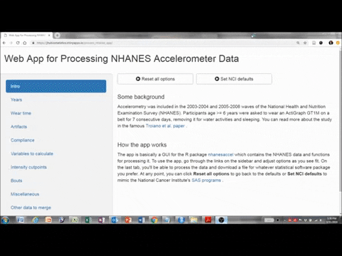

[Crowdsourced livestreams for city and neighborhood security](https://vandomed.shinyapps.io/nocrimezone/)

[figure not shown]

## Conferences - Presented

**Van Domelen, D.R.** & Zipunnikov, V. (2019; poster). Wearable devices are objective but imperfect–towards correcting for two sources of error. *ENAR 2019 Spring Meeting*. Philadelphia, PA, March 24-27, 2019. [Program](https://enar.org/meetings/spring2019/program/Preliminary_Program.pdf).

**Van Domelen, D.R.**, Mitchell, E.M., Schisterman, E.F., Perkins, N.J., & Lyles, R.H. (2018; SPEED talk/e-poster). Logistic regression with a right-skewed exposure variable measured in pools and subject to errors. *2018 Joint Statistical Meeting*. Vancouver, BC, July 28-Aug. 2, 2018. [Abstract](https://ww2.amstat.org/meetings/jsm/2018/onlineprogram/AbstractDetails.cfm?abstractid=330748).

**Van Domelen, D.R.** (2017; invited talk). Accelerometry: A better method, and a new set of problems. *2017 Duke Industry Statistics Symposium*. Durham, NC, Sep. 6-8, 2017. [Slides](https://sites.duke.edu/diss2017/files/2017/09/S3B_dane_slides.pdf).

**Van Domelen, D.R.**, Mitchell E.M., Manatunga A.K., Lyles R.H., & Schisterman, E.F. (2017; talk). Maximum likelihood-based regression with a continuous exposure variable assessed in pools and subject to measurement and processing errors. *2017 Joint Statistical Meeting*. Baltimore, MD, July 29-Aug. 3, 2017. [Abstract](https://ww2.amstat.org/meetings/jsm/2017/onlineprogram/AbstractDetails.cfm?abstractid=323769).

**Van Domelen, D.R.**, Lyles, R.H., Mitchell, E.M., & Schisterman, E.F. (2015; poster). A comparison of methods to address unmeasured confounding when internal or external validation data are available. *2015 Joint Statistical Meeting*. Seattle, WA, Aug. 8-13, 2015. [Abstract](https://www.amstat.org/meetings/jsm/2015/onlineprogram/AbstractDetails.cfm?abstractid=317289).

**Van Domelen, D.R.**, Koster, A., Caserotti, P., Brychta, R.J., Chen, K.Y., McClain J.J., Troiano, R.P., Berrigan, D., & Harris, T.B. (2010; poster). Employment and daily physical activity in America. *ACSM Conference on Integrative Physiology of Exercise*. Miami Beach, FL, Sep. 22-25, 2010.

**Van Domelen, D.R.** (2008; talk). Molecular structure of the trimeric HIV-1 envelope glycoprotein. *Biomedical Engineering Summer Internship Program Symposium*. Bethesda, MD, Aug. 8, 2008.

**Van Domelen, D.R.** (2007; talk). Centrifugal (CD) microfluidic solid-phase extraction. *Integrated Micro/nano Summer Undergraduate Research Experience Symposium*. Irvine, CA, Aug. 29, 2007. [Slides](http://www.urop.uci.edu/im-sure/2007_summer/21/21.html).

## Conferences & Presentations - Contributed

Steeves, J., Tudor-Locke, C., Murphy, R.A., King, G.A., Bassett, D.R., **Van Domelen, D.R.**, Schuna, J.M., & Harris, T.B. (2018). Objectively measured physical activity across occupations based on the NHANES. *Gerontological Society of America 70th Annual Scientific Meeting*. Boston, MA, Nov. 14-18, 2018. [Abstract](https://www.ncbi.nlm.nih.gov/pmc/articles/PMC6228651/pdf/igy023.239.pdf).

Harris, T.B., Chen, K.Y., Brychta, R.J., Caserotti, P., Shiroma, E.J., **Van Domelen, D.R.**, Launer, L.J., Gudnason, V., Arnardottir, N.Y., Sveinsson, T., Johannsson, E., Eiriksdottir, G., & Koster, A. (2016). Daily physical activity and mortality risk in the very old: Age, Gene/Environment-Reykjavik Study. *ACSM Annual Meeting*. Boston, MA, May 31-June 4, 2016. [Abstract](http://journals.lww.com/acsm-msse/Fulltext/2016/05001/Daily_Physical_Activity_And_Mortality_Risk_In_The.1660.aspx).

Patel, K.V., Morgan, J., Turk, D., & **Van Domelen, D.R.** (2016). Self-reported and objectively monitored physical activity in a nationally-representative sample of adults with and without chronic pain. *American Pain Society Annual Scientific Meeting*. Austin, TX, May 11-14. Abstract.

Gillespie, S., McCracken, C., **Van Domelen, D.R.**, & Leong, T. (2014). Multi-center clinical trials reporting with R. *useR! The R User Conference 2014*. Los Angeles, CA, June 30-July 3, 2014. [Abstract](http://user2014.stat.ucla.edu/abstracts/posters/161_Gillespie.pdf).

Koster, A., **Van Domelen, D.R.**, Caserotti, P., Brychta, R.J., Chen, K.Y., Arnardottir, N.Y., Eiriksdottir, G., Sveinsson, B., Johannsson, E., Gudnason, V., Launer, L.J., & Harris, T.B. (2013). The use of triaxial accelerometry data to define nonwear time. *3rd International Conference on Ambulatory Monitoring of Physical Activity and Movement*. Amherst, MA, June 17-19, 2013. [Abstract](http://www.umass.edu/sphhs/sites/default/files/ICAMPAM_Slide_Poster_Composite_6.6.pdf).

Martin, K.R., Koster, A., Murphy, R.A., **Van Domelen, D.R.**, Hung, M., Brychta, R., Chen, K.Y., & Harris, T.B. (2013). Changes in daily activity patterns with advancing age among US men and women. *3rd International Conference on Ambulatory Monitoring of Physical Activity and Movement*. Amherst, MA, June 17-19, 2013. [Abstract](http://www.umass.edu/sphhs/sites/default/files/ICAMPAM_Slide_Poster_Composite_6.6.pdf).

Tom, S. E., Martin, K.R., **Van Domelen, D.R.**, & Patel, K.V. (2013). Associations between daytime sleepiness and sleep duration with accelerometer-measured physical activity in NHANES 2005-2006. *3rd International Conference on Ambulatory Monitoring of Physical Activity and Movement*. Amherst, MA, June 17-19, 2013. [Abstract](http://www.umass.edu/sphhs/sites/default/files/ICAMPAM_Slide_Poster_Composite_6.6.pdf).

Harris, T.B., Caserotti, P., Chen, K., Glynn, N., Brychta, R., Matthews, C., Maia, B.L., **Van Domelen, D.R.**, Shen, H.M., Hung, M., & Koster, A. (2013). Aging research evaluating accelerometry: methodologic comparisons of accelerometry performance in the very old. *3rd International Conference on Ambulatory Monitoring of Physical Activity and Movement*. Amherst, MA, June 17-19, 2013. [Abstract](http://www.umass.edu/sphhs/sites/default/files/ICAMPAM_Slide_Poster_Composite_6.6.pdf).

Pantell, M.S., Patel, K.V., Harris, T.B., & **Van Domelen, D.R.** (2012). Socioeconomic status, race/ethnicity, and physical activity as measured by accelerometry: Which direction does the social gradient go and for whom? *140th APHA Annual Meeting and Exposition*. San Francisco, CA, Oct. 27-31, 2012. [Abstract](https://www.researchgate.net/publication/266791539_Socioeconomic_status_raceethnicity_and_physical_activity_as_measured_by_accelerometry_Which_direction_does_the_social_gradient_go_and_for_whom).

Patel, K.V., Koster, A., Caserotti, P., **Van Domelen, D.R.**, & Harris, T.B. (2011). Association of free-living physical activity and sedentary behavior with the red cell distribution width. *Gerontological Society of America 64th Annual Scientific Meeting*. Boston, MA, Nov. 18-22, 2011.

## Peer Reviewer

- [*BMC Medical Research Methodology*](https://bmcmedresmethodol.biomedcentral.com/)
- [*BMC Public Health*](https://bmcpublichealth.biomedcentral.com/)
- [*Environmentrics*](https://onlinelibrary.wiley.com/journal/1099095x)
- [*International Journal of Behavioral Nutrition and Physical Activity*](https://ijbnpa.biomedcentral.com/)
- [*Journal of Physical Activity & Health*](http://journals.humankinetics.com/journal/jpah)
- [*Journal of Aging and Physical Activity*](http://journals.humankinetics.com/journal/japa)
- [*Medicine & Science in Sports & Exercise*](http://www.acsm.org/public-information/acsm-journals/medicine-science-in-sports-exercise)

## Teaching Activities

*2013-2018: Teaching assistant, Emory University, Atlanta, GA*

- BIOS 545: Introduction to R programming (8 semesters).
- BIOS 506: Biostatistical Methods I (1 semester).
- Help students during lab, hold weekly office hour, grade homework and exams.

*2007-2008: TRIO tutor, Milwaukee School of Engineering, Milwaukee, WI*

- Program provides tutoring for students from disadvantaged backgrounds.
- Tutored chemistry, statistics, and engineering courses (150+ hours).

## Volunteerism

*2016-2018: Charity poker, Atlanta, GA*

- Host $10 buy-in poker tournaments. Winner chooses charity to donate pot to.
- Raised $1,075 for charities including [Guide Dog Foundation](https://www.guidedog.org/), [Partners in Health](https://www.pih.org/), and [World Food Programme](http://www1.wfp.org/).

*2016-8: Tutor for charity, Atlanta, GA*

- Tutor Emory students in biostatistics.
- Give 100% of earnings to [Share the Meal](https://sharethemeal.org/en/index.html) mobile app.
- Raised over $1,800.

*2014-2018: Big Brothers Big Sisters, Atlanta, GA*

- Weekly volunteer and part of “Mentoring Towards College” program.
- Homework, pizza, and Nerf wars.

*2009: Bike & Build*

- Rode bicycle from Charleston, SC, to Santa Cruz, CA, in group of 32 young adults.
- Raised $4,000 for affordable housing; helped build homes throughout U.S.

*2007-2008: Big Brothers Big Sisters, Milwaukee, WI*

- Weekly volunteer with 13-year old boy.
- Homework, sports, museums, etc.

## Extracurriculars

*2012-2017: Captain of Emory biostatistics intramural sports teams, Atlanta, GA*

- Organized teams for flag football (6 seasons) and volleyball (3 seasons).
- Rarely won but played with heart.

*2006-2009: President of racquet-sports club at Milwaukee School of Engineering, Milwaukee, WI*

- Organized tournaments for table tennis, racquetball, and foosball.

*2008: Club lacrosse at Milwaukee School of Engineering, Milwaukee, WI*

- Played midfielder for one season.

*2005-2006: Varsity golf at Milwaukee School of Engineering, Milwaukee, WI*

- Played for two seasons.